# day3_SCHMITZ.R

laura

2025-11-30

**Setup**

```r
require(tidyverse)
require(limma)
require(patchwork)
```

```r
require(ComplexHeatmap)
require(msigdbr)
setwd("G:/My Drive/. PLUS/. MASTER Medical Biology/ALL COURSES/UE Hands-on Biomedical Data – Resources and Analysis Tools (4.5 ECTS)/Teil Fortelny")
data <- readRDS("data.RDS")
metadata <- readRDS("design.RDS")
gmap <- readRDS("gmap.RDS")
MSigDB <- readRDS("MSigDB.rds")
```

**Subsetting data**

**3.1) Filter the metadata table for liver fibroblasts only and subset the data matrix by selecting only the columns that are in the filtered metadata table. How many samples do we end up with?**

> 20 samples

```r
metadata <- metadata %>%
  filter(
    grepl("GP38pos", cell_type),
    organ == "Liver"
  )

data <- data[, colnames(data) %in% rownames(metadata)]
stopifnot(ncol(data) == nrow(metadata))

dim(data)
```

```
## [1] 22055    20
```

**I again changed the row names to make it visually better in the graphs:**

```r
rownames(metadata) <-
  rownames(metadata) |>
  (\(x) gsub("Liver_Fibroblasts_", "LF_", x))() |>
  (\(x) gsub("_RNA_", "_", x))()

colnames(data) <-
  colnames(data) |>
  (\(x) gsub("Liver_Fibroblasts_", "LF_", x))() |>
  (\(x) gsub("_RNA_", "_", x))()
```

**Correlation analysis**

**Generate a heatmap of the correlation matrix and MDS projection**

### Correlation heatmap:

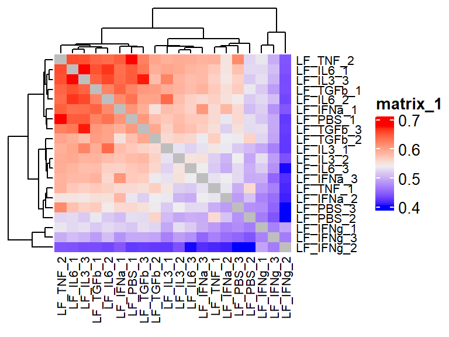

```r
corMT <- cor(data, method = "spearman")
diag(corMT) <- NA # removes the diagonal
Heatmap(corMT,
        row_names_gp = gpar(fontsize = 8),
        column_names_gp = gpar(fontsize = 8))
```

### MDS Projection:

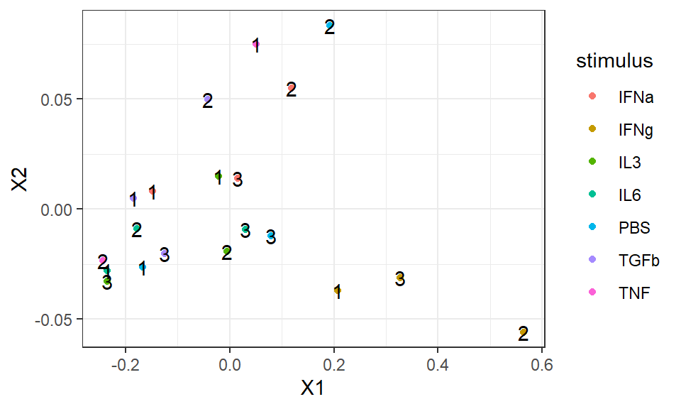

```r
data.frame(cmdscale(dist(2-corMT),eig=TRUE, k=2)$points) |>
  add_column(stimulus = metadata$stimulus) |>
  rownames_to_column("sample") |>
  mutate(sn = str_replace(sample, "^.+?_(\\d)$", "\\1")) |> # This shortens the sample names to just the number at the end
  ggplot(aes(x=X1,y=X2)) +
  geom_point(aes(color=stimulus)) +
  geom_text(aes(label=sn)) +
  theme_bw()
```

**Differential expression and data normalization**

**`Setting up the model matrix`**

```r
metadata <- metadata |>
  mutate(stimulus = as.factor(stimulus)) |>
  mutate(stimulus = relevel(stimulus, ref = "PBS"))
levels(metadata$stimulus)
```

```
## [1] "PBS"  "IFNa" "IFNg" "IL3"  "IL6"  "TGFb" "TNF"
```

```r
model_matrix <- model.matrix(~ stimulus, data = metadata)
```

**3.2) Provide the heatmap of the model matrix. Which coefficient from the model matrix compares which groups?**

**Intercept** corresponds to **PBS** control and **stimulus** corresponds to **the different stimuli by TGFb, IL6, IL3, IFNg, IFNa, and TNF**.

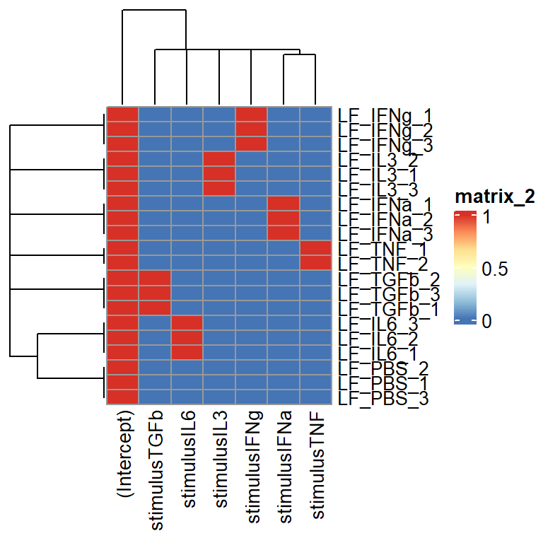

```r
pheatmap(model_matrix)
```

**`Data normalization with dataVoom`**

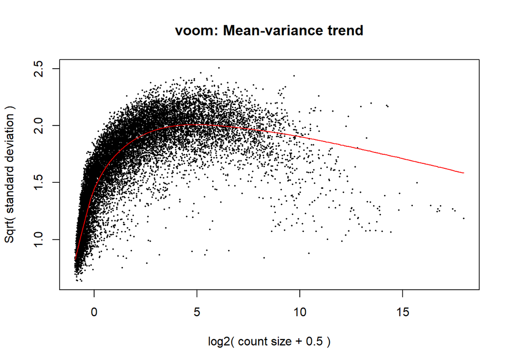

```r
dataVoom <- voom(data, design=model_matrix, plot = TRUE)
```

**`Differential expression with limmaFit`**

Fitting the differential expression model:

```r
limmaFit <- lmFit(dataVoom, design=model_matrix)
limmaFit <- eBayes(limmaFit)
head(coef(limmaFit))
```

```
##                    (Intercept) stimulusIFNa stimulusIFNg stimulusIL3
## ENSMUSG00000000001    4.147749   -1.7463170   -5.6937386   1.4731393
## ENSMUSG00000000003   -3.321538   -0.9616336   -0.5629448  -0.4088639
## ENSMUSG00000000028   -2.820756   -1.4624150   -1.0637263   2.5259338
## ENSMUSG00000000037   -2.820756   -1.4624150   -1.0637263  -0.9096454
## ENSMUSG00000000049    6.692650   -0.3227588   -6.5329779  -0.4774751
## ENSMUSG00000000056   -2.911151   -1.1365835   -0.9733315   2.7971758
##                    stimulusIL6 stimulusTGFb stimulusTNF
## ENSMUSG00000000001   0.3376983   0.06312973  -3.7295118
## ENSMUSG00000000003  -0.8674132  -0.64305310  -0.9712891
## ENSMUSG00000000028  -0.2166554   0.07595128   2.9662139
## ENSMUSG00000000037  -1.3681947  -0.58948795  -1.4720706
## ENSMUSG00000000049  -3.7456537   1.30382715  -4.3455541
## ENSMUSG00000000056   2.8932792   1.91922760  -0.8506402
```

Extracting results:

```r
limmaRes <- list()
for(coefx in colnames(coef(limmaFit))){
  print(coefx)
  # topTable returns the statistics of our genes. We then store the result of each coefficient in a list.
  # The rownames (ENSEMBL Gene IDs) are stored in the column with the name "ensg"
  limmaRes[[coefx]] <- topTable(limmaFit, coef=coefx,number = Inf) |>
    rownames_to_column("ensg")
}
```

```
## [1] "(Intercept)"
## [1] "stimulusIFNa"
## [1] "stimulusIFNg"
## [1] "stimulusIL3"
## [1] "stimulusIL6"
## [1] "stimulusTGFb"
## [1] "stimulusTNF"
```

```r
limmaRes <- bind_rows(limmaRes, .id = "coef") # bind_rows combines the results and stores the name of the coefficient in the column "coef"
limmaRes <- filter(limmaRes, coef != "(Intercept)") # then we keep all results except for the intercept
```

**Data interpretation**

**3.3) Draw a volcano plot from `limmaRes` and a histogram for P-value distribution**

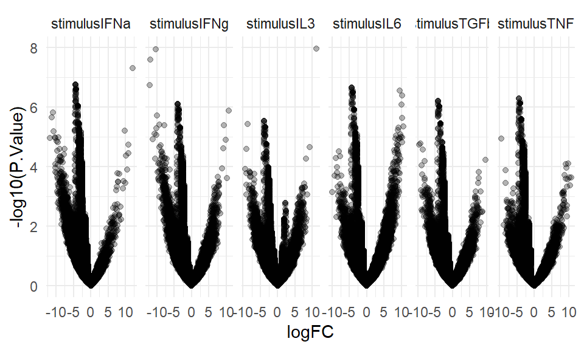

```r
ggplot(
  data = limmaRes,
  mapping = aes(x = logFC, y = -log10(P.Value))) +
  geom_point(alpha = 0.3) +
  theme_minimal() +
  facet_grid(~coef, scales = "free", space = "free")
```

```r
labs(
  x = "Log2 Fold change",
  y = "-Log10 P-value"
)
```

```
## <ggplot2::labels> List of 2
##  $ x: chr "Log2 Fold change"
##  $ y: chr "-Log10 P-value"
```

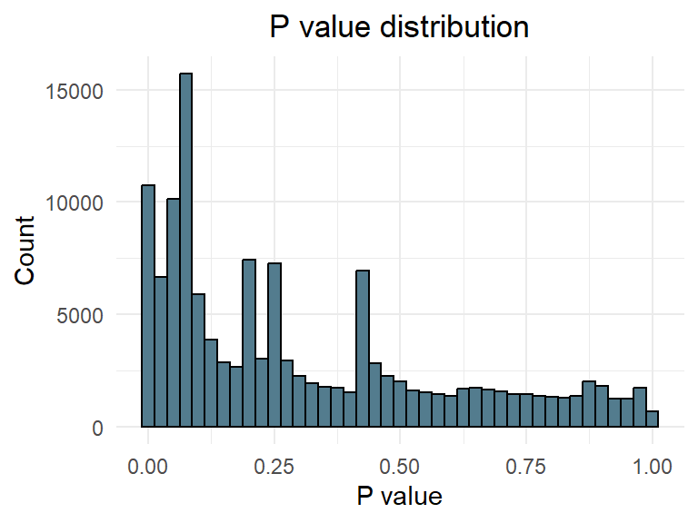

```r
ggplot(limmaRes,
       aes(x = P.Value)) +
  geom_histogram(binwidth = 0.025, fill = "#537C8E", color = "#000000")  +
  theme_minimal() +
  labs(
    title = "P value distribution",
    x = "P value",
    y = "Count") +
  theme(
    plot.title = element_text(hjust = 0.5)  # center the title
  )
```

**3.4) Report the number of tested and significant genes for each comparison. Report the code (should just be a few lines) you use to answer the questions.**

```r
limmaRes %>% count()
```

```
##        n
## 1 132330
```

```r
limmaResSig <- limmaRes %>%
  filter(adj.P.Val <= 0.05, AveExpr > 1)
count(limmaResSig)
```

```
##     n
## 1 207
```

**Visualizing results**

**3.5) Visualizing one gene**

Chosen gene: **ENSMUSG00000078920**: is in the top 5 highest logFC values.

```r
top_5 <- limmaResSig %>%
  slice_max(order_by = logFC, n = 5)
top_5
```

```
##           coef               ensg    logFC  AveExpr        t      P.Value
## 1 stimulusIFNa ENSMUSG00000078920 10.95911 4.571534 4.903476 3.546494e-05
## 2 stimulusIFNa ENSMUSG00000034459 10.93058 1.738763 5.148303 1.811674e-05
## 3  stimulusTNF ENSMUSG00000078920 10.70654 4.571534 4.210995 2.352255e-04
## 4 stimulusIFNa ENSMUSG00000034855 10.60134 3.287966 4.437794 1.269257e-04
## 5  stimulusIL6 ENSMUSG00000016257 10.22353 1.602616 5.203891 1.555542e-05
##     adj.P.Val          B
## 1 0.002773685  0.6415813
## 2 0.001730636  0.6762379
## 3 0.009496786 -0.8561337
## 4 0.004228620 -0.3747296
## 5 0.002174354  1.5823312
```

Visualizing it:

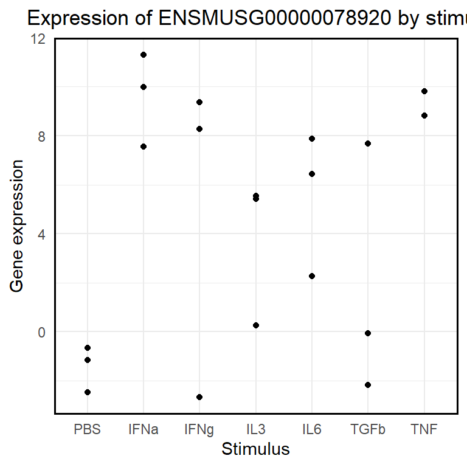

```r
metadata_3.5 <- metadata |> mutate(Expression_GeneOfInterest=dataVoom$E["ENSMUSG00000078920", ])

ggplot(metadata_3.5,
       aes(x = stimulus,
           y = Expression_GeneOfInterest)) +
  geom_point() +
  theme_minimal() +
  labs(
    title = "Expression of ENSMUSG00000078920 by stimuli",
    x = "Stimulus",
    y = "Gene expression") +
  theme(
    plot.title = element_text(hjust = 0.5),  # center the title
    panel.border = element_rect(color = "black", fill = NA, size = 1)  # black border
  )
```

The plot shows highest expression for stimulus with IFNa and TNF, and lowest expression for PBS and TGFb. This goes along with the logFC calculated for these stimuli (the most positive logFC = the highest expression in comparison to the reference PBS)

```r
limmaRes %>%
  filter(ensg == "ENSMUSG00000078920") %>%
  select(coef, logFC) %>%
  arrange(desc(logFC))
```

```
##           coef     logFC
## 1 stimulusIFNa 10.959114
## 2  stimulusTNF 10.706540
## 3  stimulusIL6  6.939114
## 4 stimulusIFNg  6.312466
## 5  stimulusIL3  5.174852
## 6 stimulusTGFb  3.195291
```

**3.6) Visualizing multiple genes**

**Getting top 5 genes by logFC per group (coef)**

```r
goi.all <- limmaResSig %>% group_by(coef) %>% slice_max(order_by = logFC, n = 5) %>% pull(ensg)
print(goi.all)
```

```
##  [1] "ENSMUSG00000078920" "ENSMUSG00000034459" "ENSMUSG00000034855"
##  [4] "ENSMUSG00000039910" "ENSMUSG00000028270" "ENSMUSG00000024678"
##  [7] "ENSMUSG00000031516" "ENSMUSG00000000399" "ENSMUSG00000010376"
## [10] "ENSMUSG00000026674" "ENSMUSG00000024446" "ENSMUSG00000038664"
## [13] "ENSMUSG00000033751" "ENSMUSG00000031596" "ENSMUSG00000016257"
## [16] "ENSMUSG00000068245" "ENSMUSG00000030748" "ENSMUSG00000024349"
## [19] "ENSMUSG00000024487" "ENSMUSG00000001366" "ENSMUSG00000033751"
## [22] "ENSMUSG00000045827" "ENSMUSG00000027189" "ENSMUSG00000020163"
## [25] "ENSMUSG00000078920" "ENSMUSG00000035373" "ENSMUSG00000074115"
## [28] "ENSMUSG00000035385" "ENSMUSG00000020873"
```

**`Plotting statistical results`**

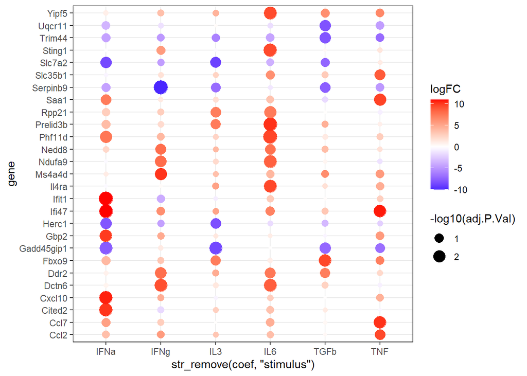

```r
(p.coef <- limmaRes |>
    filter(ensg %in% goi.all) |>
    mutate(gene = gmap[ensg,]$external_gene_name) |>
    ggplot(aes(y=gene, x=str_remove(coef, "stimulus"), color=logFC, size=-log10(adj.P.Val))) +
    geom_point() +
    scale_color_gradient2(high="red", low="blue") +
    theme_bw())
```

**`Plotting expression data`**

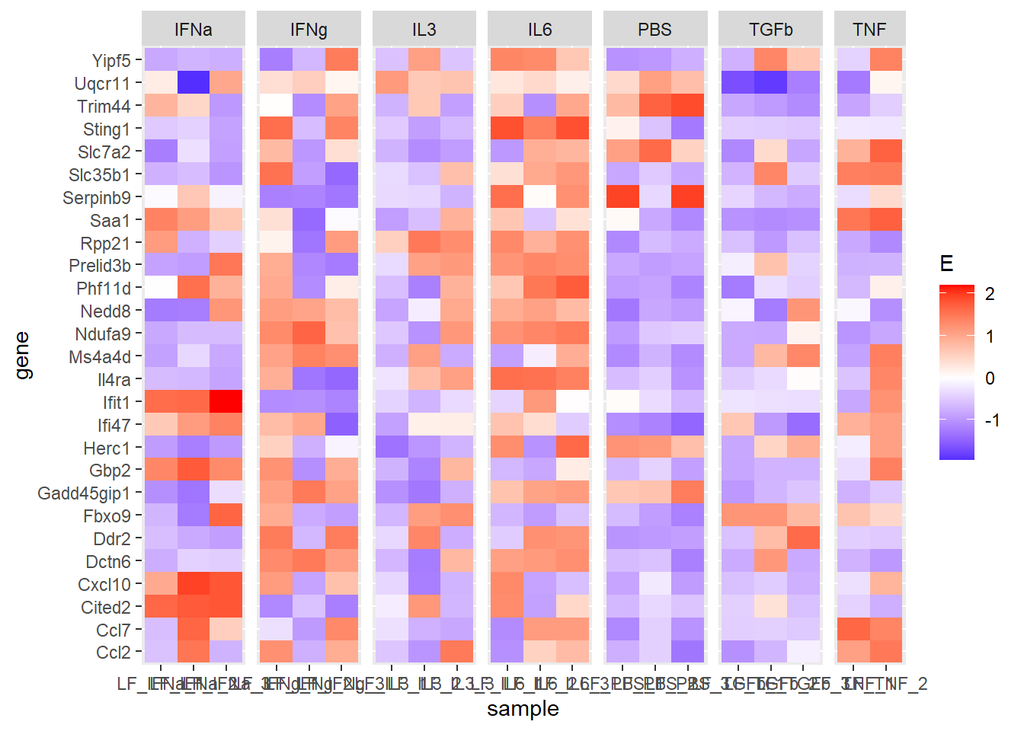

```r
dat.list <- list()
for(gg in goi.all){
  dat.list[[gg]] <- metadata |>
    mutate(E=scale(dataVoom$E[gg,])) |>
    rownames_to_column("sample") |>
    remove_rownames()
}
(p.vals <- bind_rows(dat.list, .id="ensg") |>
    mutate(gene = gmap[ensg,]$external_gene_name) |>
    mutate(stimulus = as.character(stimulus)) |>
    ggplot(aes(x=sample, y=gene, fill=E)) +
    geom_tile() +
    facet_grid(. ~ stimulus, space ="free", scales = "free") +
    scale_fill_gradient2(low="blue", high="red"))
```

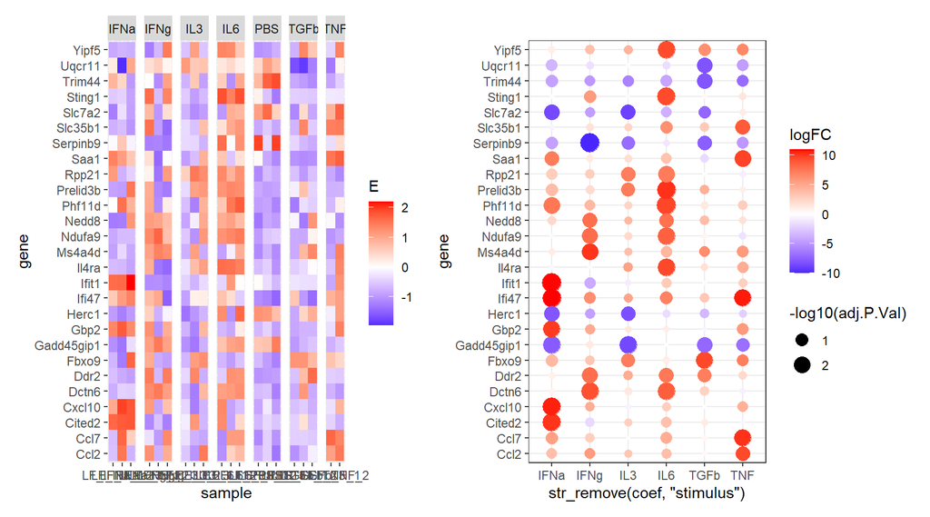

```r
p.vals + p.coef
```

**Enrichment analysis**

**`Enrichment analysis for each coefficient`**

```r
fisher_list <- list()
for(coefx in unique(limmaResSig$coef)){

  # What is coefx now?
  message(coefx)

  # Extract genes of interests (GOI) for a given coefficient (see yesterday's example)
  goi <- limmaResSig %>% filter(coef == coefx) %>% pull(ensg)
  goi <- gmap[goi, ]$external_gene_name |> unique()
  print(goi)

  universe <- unique(gmap$external_gene_name)
  universe <- unique(universe[!is.na(universe) & universe != ""])
  MSigDB <- readRDS("MSigDB.rds")
  fisher_tbl <- map_df(names(MSigDB), function(pw) {
    pw_genes <- MSigDB[[pw]]
    sig_genes <- goi
    overlap <- intersect(sig_genes, pw_genes)
    a <- length(overlap)
    b <- length(sig_genes) - a
    c <- length(pw_genes) - a
    d <- length(universe) - (a+b+c)

    ft <- fisher.test(matrix(c(a,b,c,d),2), alternative = "greater")

    tibble(
      pathway = pw,
      pvalue = ft$p.value,
      odds_ratio = as.numeric(ft$estimate),
      DE_in_pathway = a,
      overlapping_genes = paste(overlap, collapse = ",")
    )
  })
  fisher_tbl <- fisher_tbl |> mutate(p_adj = p.adjust(pvalue, "BH"))
  print(head(fisher_tbl))

  # Store results in the list
  fisher_list[[coefx]] <- fisher_tbl
}
```

```
## stimulusIFNa
```

```
##  [1] "Mcmbp"         "Slc38a3"       "Rnf125"        "Rp9"
##  [5] "Creb3l3"       "Ifit1"         "Ifi47"         "Cited2"
##  [9] "Vwa8"          "Mkln1"         "Golgb1"        "Osgin1"
## [13] "G0s2"          "Arnt"          "Cebpz"         "Tmprss6"
## [17] "Cxcl10"        "Zfp91"         "Gadd45gip1"    "Pcyt2"
## [21] "Phf11d"        "Efl1"          "Hpn"           "Adipor2"
## [25] "Rnf166"        "Ifit2"         "Pnisr"         "Hsd17b4"
## [29] "Itih2"         "Gbp2"          "Plcxd2"        "Ralgapa2"
## [33] "Tmed4"         "Vps16"         "Myh9"          "Eif2b4"
## [37] "Elob"          "Snrpe"         "Ifit3"         "Hmgn2"
## [41] "Mcoln1"        "Avpi1"         "Csnk2b"        "Mcrip1"
## [45] "Srpk2"         "Pygl"          "Aldh6a1"       "Snrpa"
## [49] "Ephx2"         "Gbf1"          "Niban1"        "Mrpl51"
## [53] "Timm13"        "Herc1"         "Sik1"          "Tsen34"
## [57] "Arhgap24"      "Wasl"          "Sun2"          "Slc7a2"
```

[output cut: 18 more lines]

```
## stimulusIFNg
```

```
##  [1] "Scgb1a1"  "Rnf125"   "Spp1"     "Serpinb9" "Jchain"   "Ptk2b"
##  [7] "Alas2"    "Dctn6"    "Vwa8"     "Cd36"     "S1pr1"    "Rbck1"
## [13] "Elf1"     "Trpm7"    "Mlxip"    "Ftcd"     "Zhx1"     "Tbc1d15"
## [19] "Araf"     "Dym"      "Cbr2"     "Gars"     "Nck1"     "Rnf6"
## [25] "Gcn1"     "Ahcyl"    "Mafb"     "Cd24a"    "Sorbs2"   "Ms4a4d"
## [31] "Mcmbp"    "Epas1"    "Mgat1"    "Ddr2"     "Dynlt3"   "Ndufa9"
## [37] "Dram2"    "Mtfr1l"   "Rnf166"   "Lrpprc"   "Parp1"    "Mea1"
## [43] "Avpi1"    "Arid4b"   "Rap1gds1" "Ptprb"    "Glyat"    "Ahcy"
## [49] "Etfb"     "Nfe2l2"   "Zc3h15"   "Pecam1"   "Msra"     "Sirt7"
## [55] "Zmym3"    "Nedd8"    "Cluh"
## # A tibble: 6 × 6
##   pathway               pvalue odds_ratio DE_in_pathway overlapping_genes  p_adj
##   <chr>                  <dbl>      <dbl>         <int> <chr>              <dbl>
## 1 HALLMARK_ADIPOGENES… 0.00184       8.31             4 "Cd36,Araf,Dram2… 0.0921
## 2 HALLMARK_ALLOGRAFT_… 0.415         1.90             1 "Nck1"            0.704
## 3 HALLMARK_ANDROGEN_R… 0.279         3.12             1 "Ptk2b"           0.704
## 4 HALLMARK_ANGIOGENES… 0.0898       11.1              1 "Spp1"            0.420
## 5 HALLMARK_APICAL_JUN… 0.407         1.95             1 "Pecam1"          0.704
## 6 HALLMARK_APICAL_SUR… 1             0                0 ""                1
```

```
## stimulusIL3
```

```
## [1] "Gadd45gip1" "Slc7a2"     "Rpp21"      "Herc1"
## # A tibble: 6 × 6
##   pathway                pvalue odds_ratio DE_in_pathway overlapping_genes p_adj
##   <chr>                   <dbl>      <dbl>         <int> <chr>             <dbl>
## 1 HALLMARK_ADIPOGENESIS       1          0             0 ""                    1
## 2 HALLMARK_ALLOGRAFT_RE…      1          0             0 ""                    1
## 3 HALLMARK_ANDROGEN_RES…      1          0             0 ""                    1
## 4 HALLMARK_ANGIOGENESIS       1          0             0 ""                    1
## 5 HALLMARK_APICAL_JUNCT…      1          0             0 ""                    1
## 6 HALLMARK_APICAL_SURFA…      1          0             0 ""                    1
```

```
## stimulusIL6
```

```
##  [1] "Phf11d"   "Prelid3b" "Yipf5"    "Dctn6"    "Sting1"   "Srp19"
##  [7] "Itgal"    "Il4ra"    "Ndufa9"   "Rasa3"    "Hk2"      "Cpne8"
## [13] "Hmox2"    "Mxd1"     "Eif3k"    "Rpp21"    "Pgs1"     "Stim1"
## [19] "Slbp"     "Maob"     "Coa3"     "Ccn1"     "Ddr2"     "Map2k3"
## [25] "Emilin1"  "Eif4g1"   "Dusp11"   "Tmem109"  "Actr1b"   "Creb3l3"
## [31] "Septin9"  "Col4a2"   "Sypl"     "Irf7"     "Tep1"     "Ppp4r3a"
## [37] "Slc40a1"
## # A tibble: 6 × 6
##   pathway               pvalue odds_ratio DE_in_pathway overlapping_genes  p_adj
##   <chr>                  <dbl>      <dbl>         <int> <chr>              <dbl>
## 1 HALLMARK_ADIPOGENES… 1             0                0 ""                1
## 2 HALLMARK_ALLOGRAFT_… 0.00493       9.49             3 "Itgal,Il4ra,Irf… 0.0616
## 3 HALLMARK_ANDROGEN_R… 0.191         4.86             1 "Srp19"           0.562
## 4 HALLMARK_ANGIOGENES… 1             0                0 ""                1
## 5 HALLMARK_APICAL_JUN… 1             0                0 ""                1
## 6 HALLMARK_APICAL_SUR… 1             0                0 ""                1
```

```
## stimulusTGFb
```

```
## [1] "Fbxo9"      "Ssu72"      "Aars"       "Trim44"     "Gadd45gip1"
## [6] "Uqcr11"     "Serpinb9"
## # A tibble: 6 × 6
##   pathway                pvalue odds_ratio DE_in_pathway overlapping_genes p_adj
##   <chr>                   <dbl>      <dbl>         <int> <chr>             <dbl>
## 1 HALLMARK_ADIPOGENESIS  0.0623       18.1             1 "Uqcr11"          0.794
## 2 HALLMARK_ALLOGRAFT_RE… 0.0636       17.8             1 "Aars"            0.794
## 3 HALLMARK_ANDROGEN_RES… 1             0               0 ""                1
## 4 HALLMARK_ANGIOGENESIS  1             0               0 ""                1
## 5 HALLMARK_APICAL_JUNCT… 1             0               0 ""                1
## 6 HALLMARK_APICAL_SURFA… 1             0               0 ""                1
```

```
## stimulusTNF
```

```
## [1] "Ccl7"    "Ifi47"   "Saa1"    "Mt2"     "Ccl2"    "Slc35b1" "Vcam1"
## # A tibble: 6 × 6
##   pathway               pvalue odds_ratio DE_in_pathway overlapping_genes  p_adj
##   <chr>                  <dbl>      <dbl>         <int> <chr>              <dbl>
## 1 HALLMARK_ADIPOGENES… 1              0               0 ""                1
## 2 HALLMARK_ALLOGRAFT_… 0.00177       42.8             2 "Ccl7,Ccl2"       0.0221
## 3 HALLMARK_ANDROGEN_R… 1              0               0 ""                1
## 4 HALLMARK_ANGIOGENES… 1              0               0 ""                1
## 5 HALLMARK_APICAL_JUN… 0.0620        18.2             1 "Vcam1"           0.292
## 6 HALLMARK_APICAL_SUR… 1              0               0 ""                1
```

**Combining results of enrichment analysis in a table:**

```r
str(fisher_list)
```

```
## List of 6
##  $ stimulusIFNa: tibble [50 × 6] (S3: tbl_df/tbl/data.frame)
##   ..$ pathway          : chr [1:50] "HALLMARK_ADIPOGENESIS" "HALLMARK_ALLOGRAFT_REJECTION" "HALLMARK_ANDROGEN_RESPONSE" "HALLMARK_ANGIOGENESIS" ...
##   ..$ pvalue           : num [1:50] 0.0114 0.5906 1 1 0.2144 ...
##   ..$ odds_ratio       : num [1:50] 4.83 1.13 0 0 2.35 ...
##   ..$ DE_in_pathway    : int [1:50] 4 1 0 0 2 1 1 3 2 2 ...
##   ..$ overlapping_genes: chr [1:50] "Adipor2,Ephx2,Tkt,Mrpl15" "Gbp2" "" "" ...
##   ..$ p_adj            : num [1:50] 0.0731 0.7981 1 1 0.4417 ...
##  $ stimulusIFNg: tibble [50 × 6] (S3: tbl_df/tbl/data.frame)
##   ..$ pathway          : chr [1:50] "HALLMARK_ADIPOGENESIS" "HALLMARK_ALLOGRAFT_REJECTION" "HALLMARK_ANDROGEN_RESPONSE" "HALLMARK_ANGIOGENESIS" ...
##   ..$ pvalue           : num [1:50] 0.00184 0.41451 0.27921 0.08981 0.40675 ...
##   ..$ odds_ratio       : num [1:50] 8.31 1.9 3.12 11.1 1.95 ...
##   ..$ DE_in_pathway    : int [1:50] 4 1 1 1 1 0 0 0 0 1 ...
##   ..$ overlapping_genes: chr [1:50] "Cd36,Araf,Dram2,Etfb" "Nck1" "Ptk2b" "Spp1" ...
##   ..$ p_adj            : num [1:50] 0.0921 0.7036 0.7036 0.4202 0.7036 ...
##  $ stimulusIL3 : tibble [50 × 6] (S3: tbl_df/tbl/data.frame)
##   ..$ pathway          : chr [1:50] "HALLMARK_ADIPOGENESIS" "HALLMARK_ALLOGRAFT_REJECTION" "HALLMARK_ANDROGEN_RESPONSE" "HALLMARK_ANGIOGENESIS" ...
##   ..$ pvalue           : num [1:50] 1 1 1 1 1 1 1 1 1 1 ...
##   ..$ odds_ratio       : num [1:50] 0 0 0 0 0 0 0 0 0 0 ...
##   ..$ DE_in_pathway    : int [1:50] 0 0 0 0 0 0 0 0 0 0 ...
##   ..$ overlapping_genes: chr [1:50] "" "" "" "" ...
##   ..$ p_adj            : num [1:50] 1 1 1 1 1 1 1 1 1 1 ...
##  $ stimulusIL6 : tibble [50 × 6] (S3: tbl_df/tbl/data.frame)
##   ..$ pathway          : chr [1:50] "HALLMARK_ADIPOGENESIS" "HALLMARK_ALLOGRAFT_REJECTION" "HALLMARK_ANDROGEN_RESPONSE" "HALLMARK_ANGIOGENESIS" ...
##   ..$ pvalue           : num [1:50] 1 0.00493 0.19139 1 1 ...
##   ..$ odds_ratio       : num [1:50] 0 9.49 4.86 0 0 ...
##   ..$ DE_in_pathway    : int [1:50] 0 3 1 0 0 0 0 0 0 0 ...
##   ..$ overlapping_genes: chr [1:50] "" "Itgal,Il4ra,Irf7" "Srp19" "" ...
##   ..$ p_adj            : num [1:50] 1 0.0616 0.562 1 1 ...
##  $ stimulusTGFb: tibble [50 × 6] (S3: tbl_df/tbl/data.frame)
##   ..$ pathway          : chr [1:50] "HALLMARK_ADIPOGENESIS" "HALLMARK_ALLOGRAFT_REJECTION" "HALLMARK_ANDROGEN_RESPONSE" "HALLMARK_ANGIOGENESIS" ...
##   ..$ pvalue           : num [1:50] 0.0623 0.0636 1 1 1 ...
##   ..$ odds_ratio       : num [1:50] 18.1 17.8 0 0 0 ...
##   ..$ DE_in_pathway    : int [1:50] 1 1 0 0 0 0 0 0 0 0 ...
##   ..$ overlapping_genes: chr [1:50] "Uqcr11" "Aars" "" "" ...
##   ..$ p_adj            : num [1:50] 0.794 0.794 1 1 1 ...
##  $ stimulusTNF : tibble [50 × 6] (S3: tbl_df/tbl/data.frame)
##   ..$ pathway          : chr [1:50] "HALLMARK_ADIPOGENESIS" "HALLMARK_ALLOGRAFT_REJECTION" "HALLMARK_ANDROGEN_RESPONSE" "HALLMARK_ANGIOGENESIS" ...
##   ..$ pvalue           : num [1:50] 1 0.00177 1 1 0.06204 ...
##   ..$ odds_ratio       : num [1:50] 0 42.8 0 0 18.2 ...
##   ..$ DE_in_pathway    : int [1:50] 0 2 0 0 1 0 0 0 0 0 ...
##   ..$ overlapping_genes: chr [1:50] "" "Ccl7,Ccl2" "" "" ...
##   ..$ p_adj            : num [1:50] 1 0.0221 1 1 0.2916 ...
```

```r
fisher_tbl <- bind_rows(fisher_list, .id = "coef")
head(fisher_tbl)
```

```
## # A tibble: 6 × 7
##   coef         pathway  pvalue odds_ratio DE_in_pathway overlapping_genes  p_adj
##   <chr>        <chr>     <dbl>      <dbl>         <int> <chr>              <dbl>
## 1 stimulusIFNa HALLMAR… 0.0114       4.83             4 "Adipor2,Ephx2,T… 0.0731
## 2 stimulusIFNa HALLMAR… 0.591        1.13             1 "Gbp2"            0.798
## 3 stimulusIFNa HALLMAR… 1            0                0 ""                1
## 4 stimulusIFNa HALLMAR… 1            0                0 ""                1
## 5 stimulusIFNa HALLMAR… 0.214        2.35             2 "Myh9,Wasl"       0.442
## 6 stimulusIFNa HALLMAR… 0.175        5.37             1 "Adipor2"         0.442
```

**3.7) Generate an enrichment analysis plot (top 10 pathways based on most significant(lowest p-value) per coef.)**

```r
top_10 <- fisher_tbl %>%
  mutate(
    coef = sub("^stimulus", "", coef),   # removing the prefix "stimulus"
  ) %>%
  group_by(coef) %>%
  arrange(p_adj, .by_group = TRUE) %>%
  slice_head(n = 10) %>%
  ungroup()
```

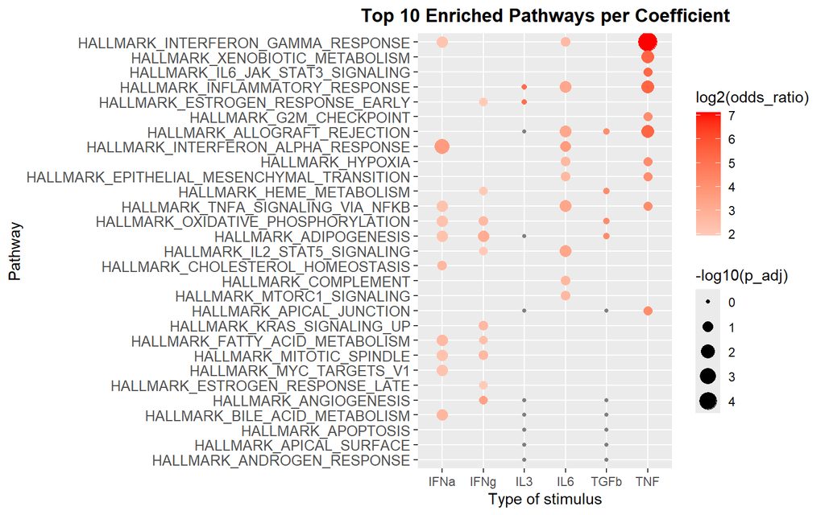

```r
ggplot(top_10, aes(
  x = coef,
  y = reorder(pathway, odds_ratio),
  size = -log10(p_adj),
  color = log2(odds_ratio)
)) +
  geom_point() +
  scale_size_continuous(name = "-log10(p_adj)") +
  scale_color_gradient2(low = "white", high = "red", name = "log2(odds_ratio)") +
  labs(
    x = "Type of stimulus",
    y = "Pathway",
    title = "Top 10 Enriched Pathways per Coefficient"
  ) +
  theme(
    axis.text.y = element_text(size = 10),
    plot.title = element_text(face = "bold", hjust = 0.5)
  )
```

**Extracting genes underlying the above enrichments**

```r
goi.enr <- fisher_tbl |>
  filter(p_adj < 0.05 & odds_ratio > 5) |>
  pull("overlapping_genes") |>
  str_split(",") |>
  unlist() |>
  unique()

limmaRes.filter <- limmaRes %>%
  mutate(
    coef = sub("^stimulus", "", coef),   # removing the prefix "stimulus"
    gene = gmap[ensg,]$external_gene_name # making "gene" column
  ) %>%
  filter(gene %in% goi.enr)
```

**3.8) From this table, generate the following plot and discuss whether the pathways are expected.**

The **Top 10 enriched pathways** graph (exercise 3.7) showed the highest enrichment of pathways for TNF and IFNa stimulus. This is confirmed for this plot as well, according to expectations.

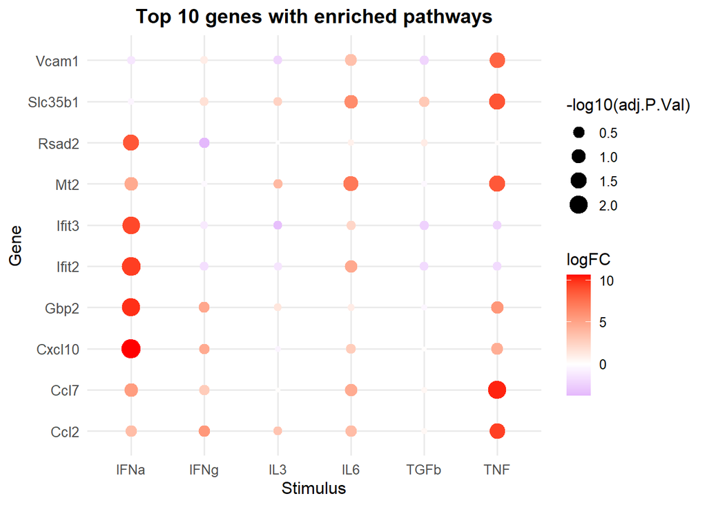

```r
limmaRes.filter |>ggplot(aes(
  x = coef,
  y = gene,
  size = -log10(adj.P.Val),
  color = logFC
)) +
  geom_point() +
  scale_size_continuous(name = "-log10(adj.P.Val)") +
  scale_color_gradient2(low = "purple", high = "red", name = "logFC") +
  labs(
    x = "Stimulus",
    y = "Gene",
    title = "Top 10 genes with enriched pathways"
  ) +
  theme_minimal(base_size = 12) +
  theme(
    axis.text.y = element_text(size = 10),
    plot.title = element_text(face = "bold", hjust = 0.5)
  )
```

**Final Questions**

**3.9) Looking at the correlation heatmap and MDS plot - do you see strong effects and clear differences between groups?**

Correlation heatmap:

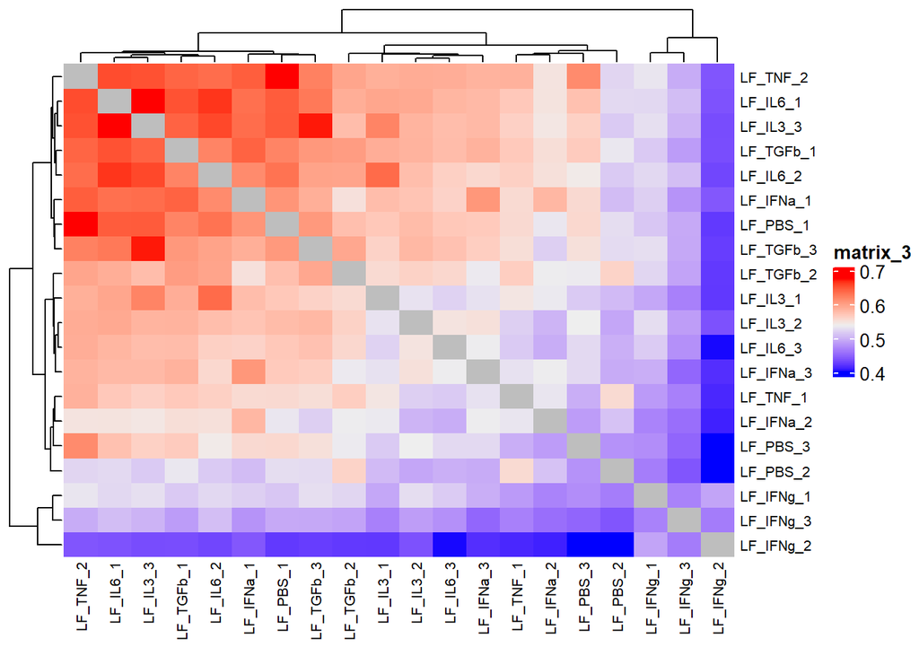

```r
Heatmap(corMT,
        row_names_gp = gpar(fontsize = 8),
        column_names_gp = gpar(fontsize = 8))
```

MDS plot:

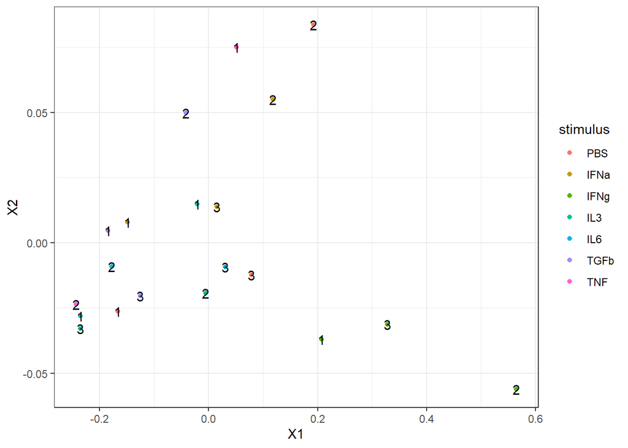

```r
data.frame(cmdscale(dist(2-corMT),eig=TRUE, k=2)$points) |>
  add_column(stimulus = metadata$stimulus) |>
  rownames_to_column("sample") |>
  mutate(sn = str_replace(sample, "^.+?_(\\d)$", "\\1")) |> # This shortens the sample names to just the number at the end
  ggplot(aes(x=X1,y=X2)) +
  geom_point(aes(color=stimulus)) +
  geom_text(aes(label=sn)) +
  theme_bw()
```

**3.10) Which treatment has the largest effects? How do you judge this? Which treatment effects most genes? Which treatment has the largest (positive or negative) log fold changes? Are those two consistent?**

The treatment with the highest effects in gene expression is **IFNa**, as judging by the **highest logFC** values:

```r
limmaRes %>%
  group_by(coef) %>%
  summarize(max_logFC = max(logFC),
            min_logFC = min(logFC)) %>%
  arrange(desc(abs(max_logFC)))
```

```
## # A tibble: 6 × 3
##   coef         max_logFC min_logFC
##   <chr>            <dbl>     <dbl>
## 1 stimulusIFNa     12.1     -11.7
## 2 stimulusIL3      11.2      -9.31
## 3 stimulusIFNg     10.8     -12.1
## 4 stimulusTNF      10.7      -9.61
## 5 stimulusIL6      10.5      -9.96
## 6 stimulusTGFb      9.51     -9.67
```

The treatment that affects the most genes is also **IFNa**, as indicated by the highest amount of significant genes (P <0.05):

```r
limmaRes %>%
  group_by(coef) %>%
  summarize(n_sig = sum(adj.P.Val < 0.05)) %>%
  arrange(desc(n_sig))
```

```
## # A tibble: 6 × 2
##   coef         n_sig
##   <chr>        <int>
## 1 stimulusIFNa  1423
## 2 stimulusIFNg  1341
## 3 stimulusIL6   1095
## 4 stimulusTNF    982
## 5 stimulusTGFb   832
## 6 stimulusIL3    336
```